# Analysis of AFI 100 Movies

The goal of this analysis is to visualize data regarding [AFI’s top 100 movies of all time](https://www.afi.com/afis-100-years-100-movies-10th-anniversary-edition/). Through these visualizations, the hope is that we can extract some insights about the film industry in general, and maybe get to know what makes a “great” movie.

This document has 2 parts: * Data wrangling: scrape information from AFI’s website, and combine it with datasets from IMDb and rufuspollock to create a dataset fit for analysis * Data visualization: where we create several charts, focusing on movie characteristics (runtime, genres), crew (actors, directors and writers) and recognition (IMDb rating, Academy Awards).

## Load libraries

Let’s first load the necessary libraries.

```r
options(warn = -1)
library(rvest)
library(tidyverse)
library(data.table)
```

```r
library(ggplot2)
options(warn = 0)
```

## Data Wrangling

This is the part where we create the dataset for the analysis.

### Extract Top 100 Movies

The first step is to extract the top 100 movies. For this, we leverage the rvest library. First, we pull the HTML of the page of interest.

```r
# use rvest library to pull the HTML
web.page <- read_html("https://www.afi.com/afis-100-years-100-movies-10th-anniversary-edition/")
```

Looking at HTML, we notice that q_title is where the titles show up. We store the data associated with this element. Since there are two tabs, this data appears twice, so we only keep the first 100 elements.

```r
# extract the elements of the class q_title
top.100.movies <- web.page %>%
                  html_nodes(".q_title") %>%
                  html_text()

# only keep the first 100 movies to avoid duplicates
top.100.movies <- top.100.movies[1:100]

#' Process a movie title as extracted from the HTML
#'
#' @param title: string extracted from the HTML
#' @return list(processed.title, release.year): a list with the title and the
#' release year
process.movie.title <- function(title) {
  # split on spaces
  split.title <- strsplit(title, " ")

  # get release year
  release.year <- split.title[[1]][length(split.title[[1]])]
  release.year <- gsub("[()]", "", release.year)

  # remove first and last elements
  split.title <- split.title[[1]][3:length(split.title[[1]]) - 1]

  # concatenate, with a space in between
  processed.title <- paste0(split.title, collapse = " ")

  return(list(processed.title, release.year))

}

# split on spaces, and remove the first and last elements of the list
# these correspond to the rank and release date of the film respectively
movie.info <- lapply(top.100.movies, process.movie.title)
top.100.movies.titles <- lapply(movie.info, function(x) {x[[1]]})
top.100.movies.release.years <- lapply(movie.info, function(x) {x[[2]]})
```

### Join with IMDb data

Various APIs for IMDb exist, but they are often of questionable legality. For this reason, we decided to work with official IMDB datasets, available [here](https://datasets.imdbws.com/). Should you want to run this code, you will need to download these files to your local machine and set the appropriate working directory

```r
setwd("~/Documents/Articles") # to be changed for your local machine
basics <- fread("title.basics.tsv.gz")
```

We currently have movie titles and release years. IMDb has persistent IDs for movies, but to get them we will need to match by title initially. Hence, the first step is to check how many titles can be matched.

```r
# get titles that are matched
matched.titles <- unique(basics[basics$originalTitle %in% top.100.movies.titles,"originalTitle"])

# unmatched titles
missing.titles <- top.100.movies.titles[!(top.100.movies.titles %in% matched.titles$originalTitle)]
missing.titles
```

```
## [[1]]
## [1] "E.T.:  The Extra-Terrestrial"
##
## [[2]]
## [1] "One Flew Over the Cuckoo's Nest "
##
## [[3]]
## [1] "Sunrise:  A Song of Two Humans"
```

We notice that 3 movies are missing: * E.T.: The Extra-Terrestrial * One Flew Over the Cuckoo’s Nest * Sunrise: A Song of Two Humans

We can ensure these are matched, by fixing various spacing errors that appear in these titles.

```r
# extract indices
index.e.t <- which(top.100.movies.titles == "E.T.:  The Extra-Terrestrial")
index.sunrise <- which(top.100.movies.titles == "Sunrise:  A Song of Two Humans")
index.cuckoo <- which(top.100.movies.titles == "One Flew Over the Cuckoo's Nest ")

# fix
top.100.movies.titles[index.e.t] <- "E.T.: The Extra-Terrestrial"
top.100.movies.titles[index.sunrise] <- "Sunrise: A Song of Two Humans"
top.100.movies.titles[index.cuckoo] <- "One Flew Over the Cuckoo's Nest"

# confirm all titles are matched
matched.titles <- unique(basics[basics$originalTitle %in% top.100.movies.titles,"originalTitle"])
length(matched.titles$originalTitle)
```

```
## [1] 100
```

Now, let’s create the dataset we will use for our data visualization exercise. The basics dataset has multiple rows per title. For our purposes, we only conserve a row if both the movie title and the release year match

```r
# filter the dataset by only keeping titles which match
base <- merge(basics, matched.titles, by.x = "originalTitle", by.y = "originalTitle")
```

```r
#' function to check if a row should be conserved: title matches with release year
#'
#' @param row: a row in the dataframe
#' @param movie.titles: dataframe of movie titles extracted from HTML
#' @param release.years: dataframe of release years extracted from HTML
#' @return boolean, whether row should be kept
check.row <- function(row, movie.titles, release.years) {
    # column 1 is the originalTitle, column 6 is the releaseYear in the row
    # get the index for the release year
    index <- which(row[1] == movie.titles)

    # check if the release year matches
    return(unname(row[6]) == release.years[index])
}
```

```r
# apply to all the rows to see which ones to save
row.mask <- as.logical(apply(base,
                             1,
                             check.row,
                             top.100.movies.titles,
                             top.100.movies.release.years))

# filter
base.filtered <- base[row.mask,]
```

In some cases, tvEpisodes or video games were released the same year. We can remove these instances. This final dataset contains one row per movie.

```r
base.filtered.final <- base.filtered[base.filtered$titleType == "movie",]

# print the list of tconst of interest, for use in Python script
# print(list(unique(base.filtered.final$tconst)))
```

### Get crew and ratings information

Now that we have this dataset, we can add crew (directors and writers), ratings and principals (actors) information. We use a dataset that was created by a separate Python script, as Python was a lot faster at all these data manipulations. Please ensure the Python script was run so that the dataset is created.

```r
setwd("~/Documents/Articles") # edit if necessary
crew <- read.csv("crew_info.csv")
crew <- crew[,2:ncol(crew)]

# remove special characters
crew <- transform(crew,
                  directors = str_remove_all(crew$directors, "\\[|\\]|\\'"),
                  actors = str_remove_all(crew$actors, "\\[|\\]|\\'"),
                  writers = str_remove_all(crew$writers, "\\[|\\]|\\'")
                  )

# make the strings into character vectors
crew <- transform(crew,
                  directors = sapply(crew$directors, str_split, ", "),
                  actors = sapply(crew$actors, str_split, ", "),
                  writers = sapply(crew$writers, str_split, ", ")
                  )
```

We can also pull in ratings information, directly from the IMDb dataset.

```r
ratings <- fread("title.ratings.tsv.gz")
```

Let’s combine these separate datasets together.

```r
data.w.ratings <- merge(base.filtered.final,
                        ratings,
                        by.x = "tconst",
                        by.y = "tconst",
                        all.x = T)

data.w.crew.ratings <- merge(data.w.ratings,
                             crew,
                             by.x = "tconst",
                             by.y = "tconst")
```

### Get Awards data

Finally, we pull in some awards information, and format the data for later analysis. This data was found [online](https://datahub.io/rufuspollock/oscars-nominees-and-winners), and would need to be downloaded for this code to run.

```r
# pull in the full dataset
setwd("~/Documents/Articles") #edit if required
awards <- read.csv("the_oscar_award.csv")

# award winners
award.winners <- awards[awards$winner == "True",]

# count the number of awards at the movie level
award.by.movie <- award.winners %>%
                    group_by(film) %>%
                    summarize(n_awards = n())

# number of nominations at the movie level
nominations.by.movie <- awards %>%
                          group_by(film) %>%
                          summarize(n_nominations = n())

# merge with the movie dataset, to form the final dataset
movie.dataset <- merge(data.w.crew.ratings, award.by.movie,
                       by.x = "primaryTitle", by.y = "film", all.x = T)
movie.dataset <- merge(movie.dataset, nominations.by.movie,
                       by.x = "primaryTitle", by.y = "film", all.x = T)

# only keep desired columns and replace NA with 0 in n_awards
movie.dataset <- movie.dataset[,c("primaryTitle",
                                  "startYear",
                                  "runtimeMinutes",
                                  "genres",
                                  "averageRating",
                                  "directors",
                                  "writers",
                                  "actors",
                                  "n_nominations",
                                  "n_awards")]

# replace NA with 0, and encode runtime as a numeric variable
movie.dataset$n_awards[is.na(movie.dataset$n_awards)] <- 0
movie.dataset$n_nominations[is.na(movie.dataset$n_nominations)] <- 0
movie.dataset$runtimeMinutes <- as.numeric(movie.dataset$runtimeMinutes)

# encode the releaseYear as a factor
movie.dataset <- movie.dataset %>%
                  mutate(releaseYear = factor(startYear))
```

## Data Visualization

We now have the dataset with all the desired information for our analysis. We can work on visualizing elements of the dataset.

### Comparative Dataset

It will be useful to have a comparative dataset, a broader set of movies from the IMDb dataset.

```r
# get comparison movies
comparison.set <- basics[basics$primaryTitle == basics$originalTitle & basics$titleType == "movie",]
comparison.set$releaseYear <- factor(comparison.set$startYear)

# add ratings info
comparison.set <- merge(comparison.set, ratings)
```

### Number of movies per year

First, let’s visualize the number of movies by release date.

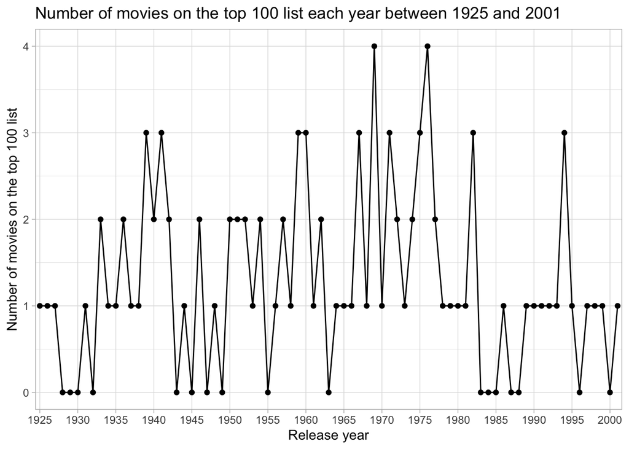

```r
# all years dataset, to merge and ensure we consider all the years
all.years <- data.frame(year = factor(c(1925:2001)))

movie.dataset %>%
  group_by(releaseYear) %>%
  summarize(n_movies = n()) %>%
  merge(all.years, by.x = "releaseYear", by.y = "year", all.y = T) %>%
  replace(is.na(.), 0) %>%
  ggplot(aes(x = releaseYear, y = n_movies)) +
  geom_point() +
  geom_line(aes(group=1)) +
  theme(axis.text.x = element_text(angle = 90)) +
  scale_x_discrete(limits= factor(c(1925:2001)), breaks = c(seq(1925, 2005,5))) +
  expand_limits(y = 0) +
  xlab("Release year") +
  ylab("Number of movies on the top 100 list") +
  ggtitle("Number of movies on the top 100 list each year between 1925 and 2001") +
  theme_light()
```

We can aggregate this data at the decade level, to figure out the most prolific decade.

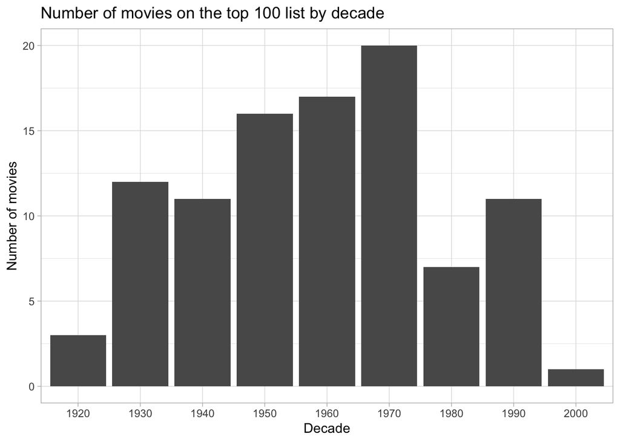

```r
movie.dataset %>%
  mutate(decade = factor(trunc(as.numeric(movie.dataset$startYear)/10)*10)) %>%
  group_by(decade) %>%
  summarize(n_movies = n()) %>%
  ggplot(aes(x = decade, y = n_movies)) +
  geom_bar(stat = "identity") +
  xlab("Decade") +
  ylab("Number of movies") +
  ggtitle("Number of movies on the top 100 list by decade") +
  theme_light()
```

### Movie characteristics

Now that we have a sense of the temporality inherent to the list, we can look at a few movie characteristics. First, the runtime and its evolution over the years.

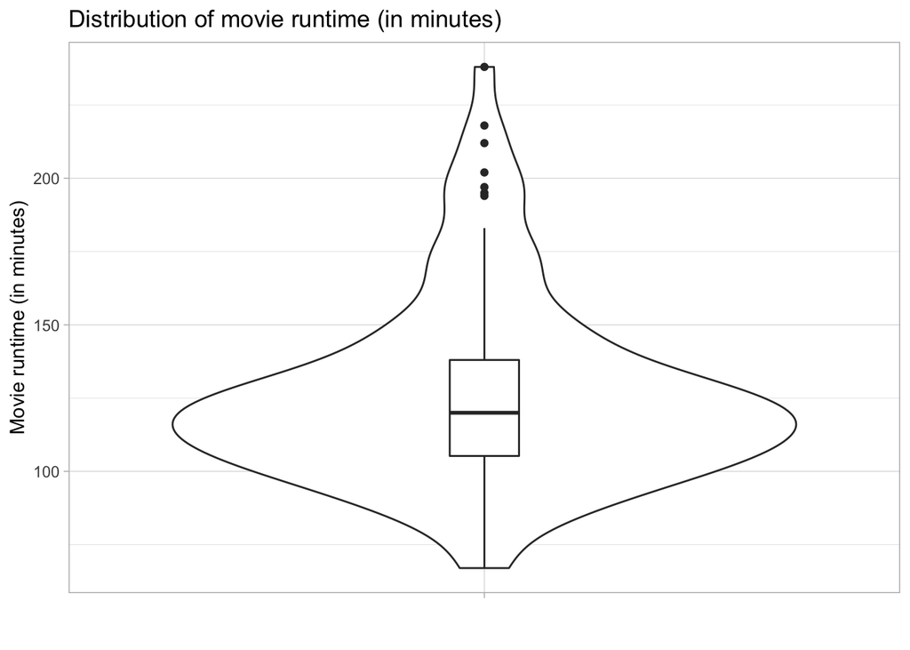

```r
movie.dataset %>%
  ggplot(aes(x = "", y = runtimeMinutes)) +
  geom_violin() +
  geom_boxplot(width=0.1) +
  theme_light() +
  ylab("Movie runtime (in minutes)") +
  xlab("") +
  ggtitle("Distribution of movie runtime (in minutes)")
```

```r
  expand_limits(y = 0)
```

```
## mapping: y = ~y
## geom_blank: na.rm = FALSE
## stat_identity: na.rm = FALSE
## position_identity
```

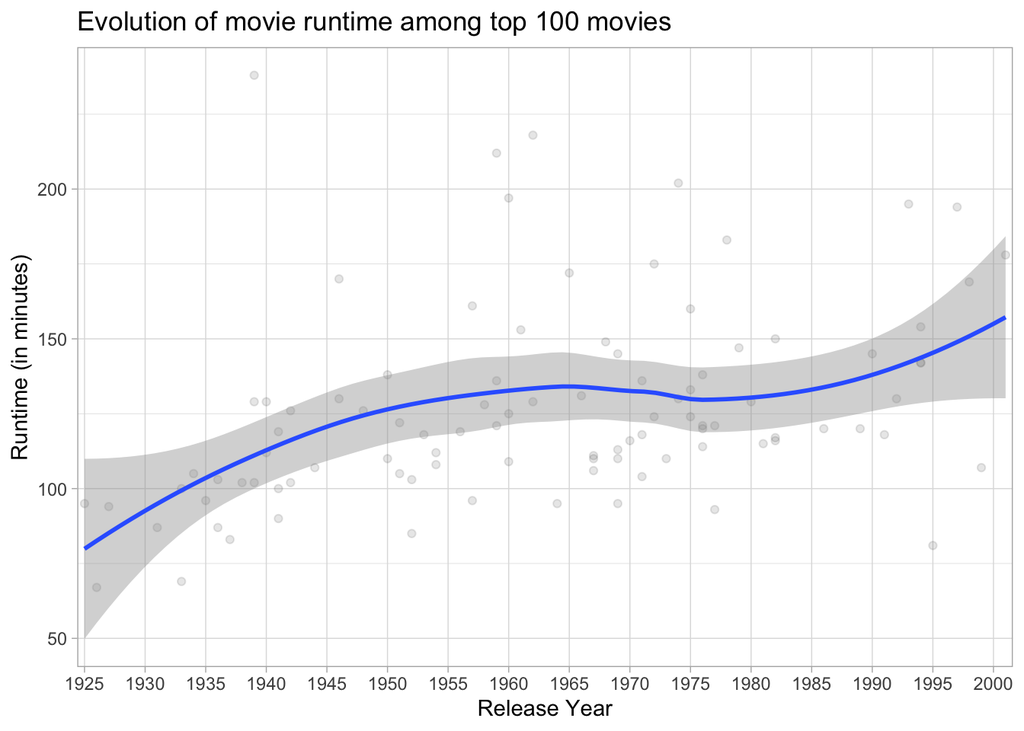

```r
movie.dataset %>%
  ggplot(aes(x = as.numeric(startYear), y = as.numeric(runtimeMinutes))) +
  geom_point(alpha = 0.1)  +
  scale_x_discrete(limits= c(1925:2001), breaks = c(seq(1925, 2005,5))) +
  stat_smooth() +
  theme_light() +
  xlab("Release Year") +
  ylab("Runtime (in minutes)") +
  ggtitle("Evolution of movie runtime among top 100 movies")
```

We can see the genres that are prevalent for each decade

```r
#' for each row in our dataset, create as many rows as there are genres
#'
#' @param row: row in a dataframe
#' @return row.genres: a dataframe with the releaseYear and all the genres
get.movie.genres <- function(row) {
  # split the genres
  genres = str_split(row[names(row) == "genres"], ",")

  # how many genres
  n.genres <- length(genres)

  # combine into a dataset
  row.genres <- data.frame(releaseYear = rep(row[names(row) == "releaseYear"],
                                             n.genres),
                           genres = genres[[1]],
                           row.names = NULL)

  return(row.genres)
}

# apply this function to all the rows and combine in a single dataframe
year.genres <- dplyr::bind_rows(apply(movie.dataset, 1, get.movie.genres))
```

First, over all 100 movies, let’s see which genres are most prevalent.

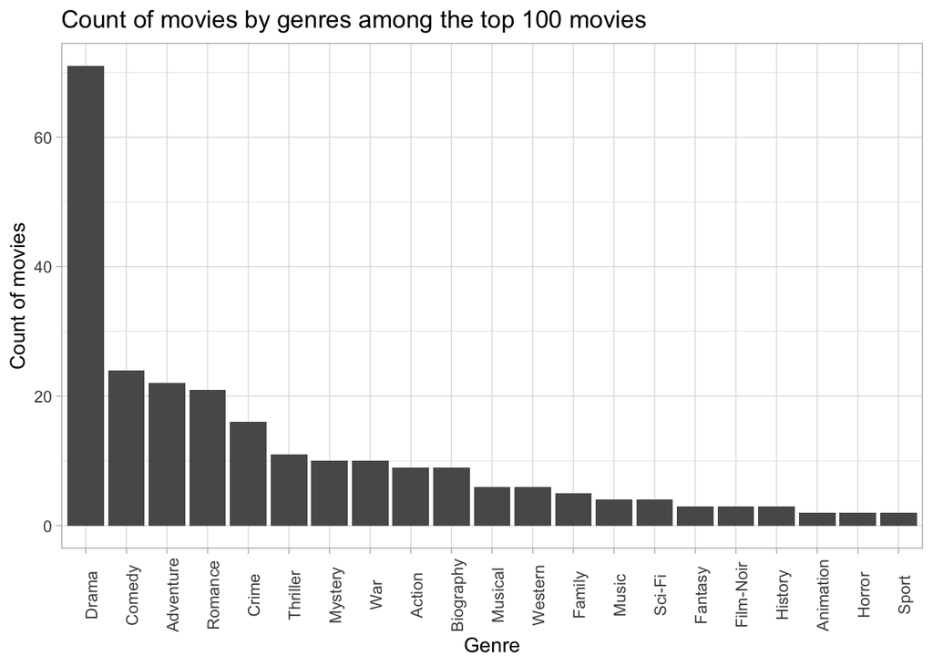

```r
year.genres %>%
  ggplot(aes(x = fct_infreq(genres))) +
  geom_bar() +
  theme_light() +
  xlab("Genre") +
  ylab("Count of movies") +
  ggtitle("Count of movies by genres among the top 100 movies") +
  theme(axis.text.x = element_text(angle = 90))
```

Let’s visualize this over time. Filter for top 5 genres above, to make the graph easier to see.

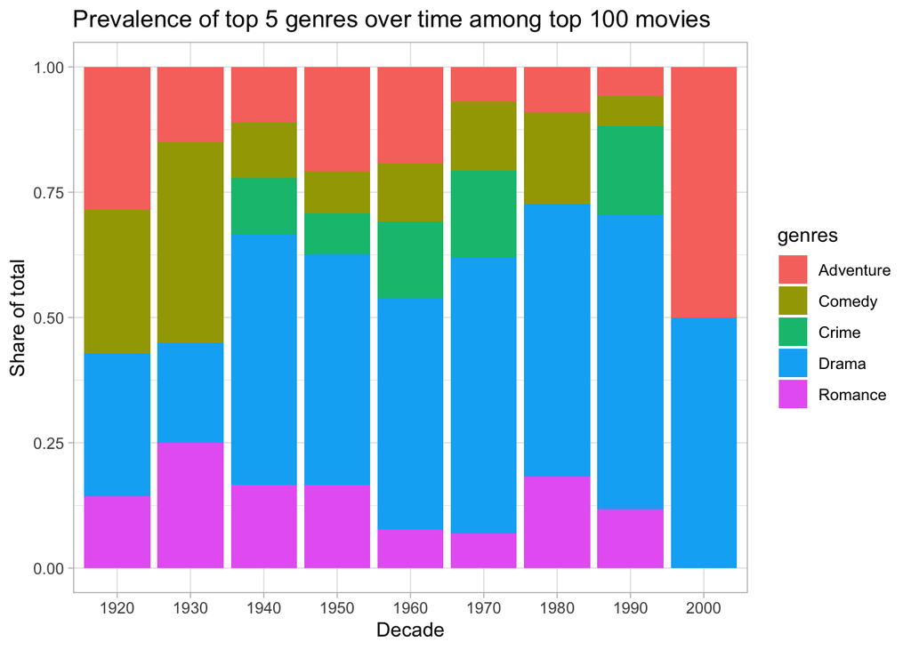

```r
# extract the top 5 genres
top.5.genres <- year.genres %>%
                  group_by(genres) %>%
                  summarize(count = n()) %>%
                  slice_max(n=5, count) %>%
                  select(genres)

# plot the proportion of these genres over time
year.genres %>%
  filter(genres %in% top.5.genres$genres) %>%
  mutate(decade = factor(trunc(as.numeric(releaseYear)/10)*10)) %>%
  group_by(decade, genres) %>%
  summarize(count = n()) %>%
  ggplot(aes(x = decade, y = count, fill = genres)) +
  geom_bar(position="fill", stat="identity") +
  theme(legend.position="top",
        axis.text.x = element_text(angle = 90)) +
  theme_light() +
  xlab("Decade") +
  ylab("Share of total") +
  ggtitle("Prevalence of top 5 genres over time among top 100 movies")
```

Similarly for the overall dataset

```r
year.genres.overall <- dplyr::bind_rows(apply(comparison.set,
                                              1,
                                              get.movie.genres))
```

We can examine the overall prevalence, and how it has changed over time.

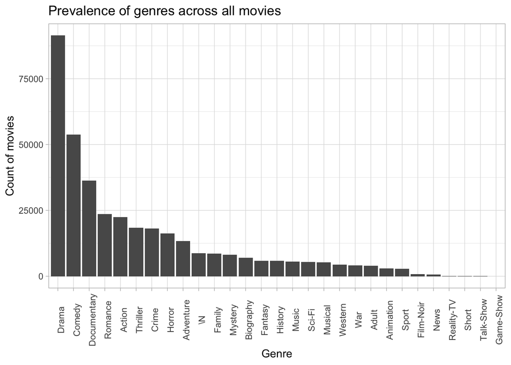

```r
year.genres.overall %>%
  ggplot(aes(x = fct_infreq(genres))) +
  geom_bar() +
  theme_light() +
  xlab("Genre") +
  ylab("Count of movies") +
  ggtitle("Prevalence of genres across all movies") +
  theme(axis.text.x = element_text(angle = 90))
```

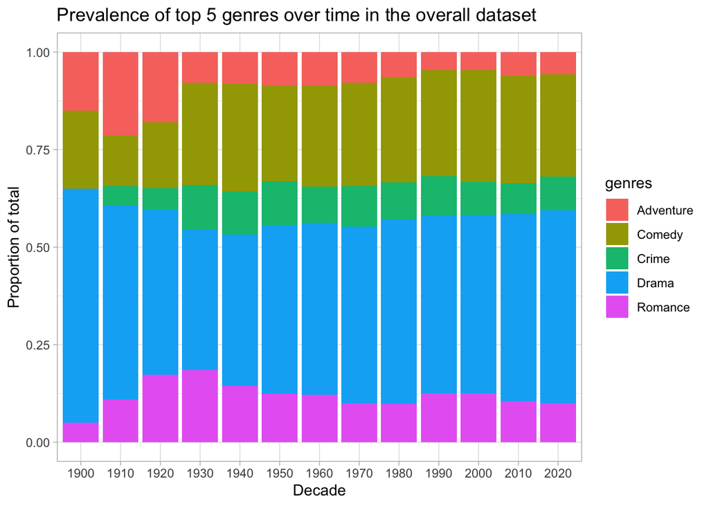

```r
year.genres.overall %>%
  filter(genres %in% top.5.genres$genres) %>%
  mutate(decade = factor(trunc(as.numeric(releaseYear)/10)*10)) %>%
  filter(!is.na(decade)) %>%
  group_by(decade, genres) %>%
  summarize(count = n()) %>%
  ggplot(aes(x = decade, y = count, fill = genres)) +
  geom_bar(position="fill", stat="identity") +
  theme(legend.position="top",
        axis.text.x = element_text(angle = 90)) +
  theme_light() +
  xlab("Decade") +
  ylab("Proportion of total") +
  ggtitle("Prevalence of top 5 genres over time in the overall dataset")
```

### People analysis

Movies are made by people. Let’s look at who’s involved: directors, writers and actors.

```r
#' create a dataframe in a long format, helper function for extract.crew.info
#' @param row: vector representing the row of a dataframe to be processed
#' @param people: string, which column we want to pull
#' @param nRep: how many times to repeat the first two fields to create the df
#' @return people.df: df in the long format format of people involved in the movie
create.long.df <- function(row, people, nRep) {
  people.df <- data.frame(
                releaseYear = rep(row[names(row) == "releaseYear"], nRep),
                primaryTitle = rep(row[names(row) == "primaryTitle"], nRep),
                type = rep(people, nRep),
                people = row[names(row) == people]
  )

  return(people.df)
}
```

```r
#' Extract crew information for a given movie
#' @param row: a row the dataframe with the desired crew information
#' @return crew.df: a dataframe with crew information in a long format
extract.crew.info <- function(row) {
  # get number of writers, directors and actors
  n.writers = length(row[names(row) == "writers"])
  n.actors = length(row[names(row) == "actors"])
  n.directors = length(row[names(row) == "directors"])

  # create dataframes in long format for each category of people
  writers.df = create.long.df(row, "writers", n.writers)
  actors.df = create.long.df(row, "actors", n.actors)
  directors.df = create.long.df(row, "directors", n.directors)

  # combine in one single dataframe for that row
  crew.df <- dplyr::bind_rows(list(writers.df, actors.df, directors.df))

  return(crew.df)
}

movie.crew.info <- dplyr::bind_rows(apply(movie.dataset, 1, extract.crew.info))

# create a name column, which coalesces values
movie.crew.info$name <- dplyr::coalesce(movie.crew.info$actors,
                                        movie.crew.info$directors,
                                        movie.crew.info$writers)
```

Let us visualize the most prevalent people in each category.

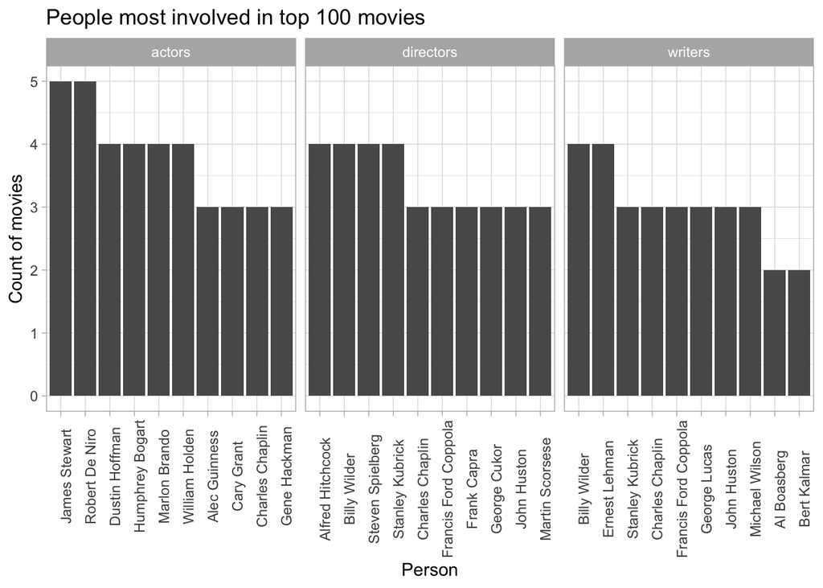

```r
movie.crew.info %>%
  group_by(type, name) %>%
  summarize(count = n()) %>%
  slice_max(n = 10, count, with_ties = F) %>%
  ggplot(aes(x = reorder(name, -count), y = count)) +
  geom_bar(stat = "identity") +
  facet_wrap(~type, scales = "free_x") +
  theme_light() +
  xlab("Person") +
  ylab("Count of movies") +
  ggtitle("People most involved in top 100 movies") +
  theme(axis.text.x = element_text(angle = 90))
```

Let us examine the rise and fall of these big actors over time.

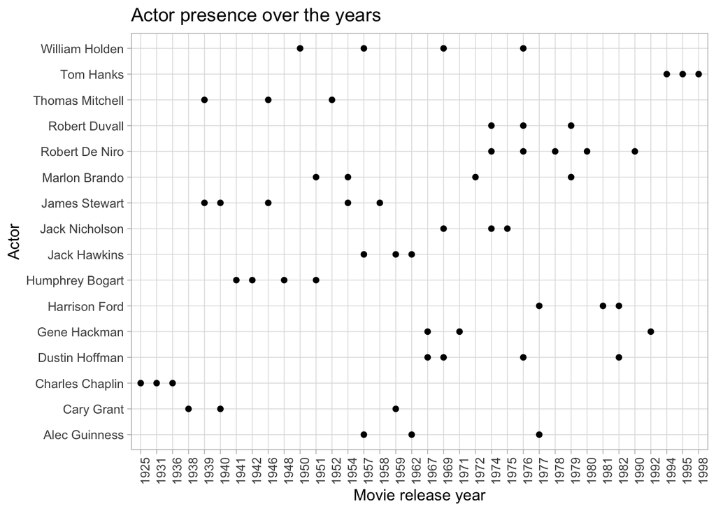

```r
# get the top 15 most represented actors
famous.actors <-
  movie.crew.info %>%
    filter(type == "actors") %>%
    group_by(name) %>%
    summarize(count = n()) %>%
    slice_max(n = 15, count)

# get all the movies from these actors
movie.crew.info %>%
  filter(type == "actors" & name %in% famous.actors$name) %>%
  ggplot(aes(x = releaseYear, y = name)) +
  geom_point() +
  theme_light() +
  theme(axis.text.x = element_text(angle = 90)) +
  xlab("Movie release year") +
  ylab("Actor") +
  ggtitle("Actor presence over the years")
```

### Recognition

These movies were judged to be most culturally significant by the American Film Institute. Do the ratings and awards receive reflect this? We can first compare IMDb ratings for these top 100 movies, and for the comparison dataset.

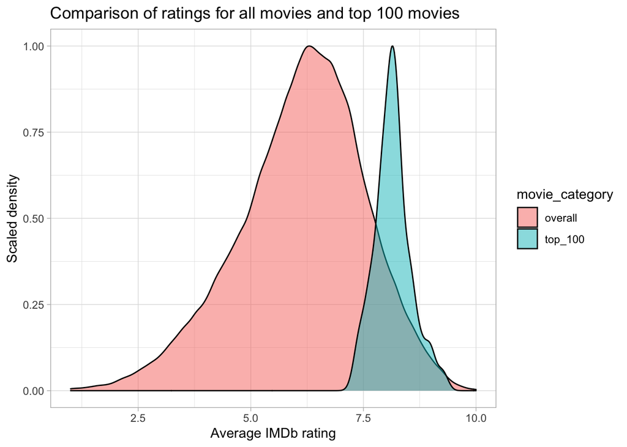

```r
# create combined dataset, to compare overall ratings distribution to top 100 distribution
movie.dataset$movie_category <- "top_100"
comparison.set$movie_category <- "overall"
compare.ratings.df <- dplyr::bind_rows(movie.dataset[,c("releaseYear",
                                                        "movie_category",
                                                        "averageRating")],
                                    comparison.set[,c("releaseYear",
                                                      "movie_category",
                                                      "averageRating")])

compare.ratings.df %>%
  ggplot(aes(x = averageRating, y = ..scaled.., fill = movie_category)) +
  geom_density(alpha = 0.5) +
  theme_light() +
  xlab("Average IMDb rating") +
  ylab("Scaled density") +
  ggtitle("Comparison of ratings for all movies and top 100 movies")
```

Visually, these distributions are different. We can confirm this visual intuition with a numerical test, using Kolmogorov-Smirnov.

```r
ks.test(averageRating ~ movie_category, data = compare.ratings.df)
```

```
##
##  Asymptotic two-sample Kolmogorov-Smirnov test
##
## data:  averageRating by movie_category
## D = 0.80487, p-value < 2.2e-16
## alternative hypothesis: two-sided
```

Then, we can visualize the highest rated movies in the top 100 dataset.

[figure not shown]

```r
movie.dataset %>%
  slice_max(n = 5, averageRating) %>%
  ggplot(aes(x = reorder(primaryTitle, -averageRating), y = averageRating)) +
  geom_bar(stat = "identity") +
  ggtitle("Highest Rated Movies in our Top 100 Dataset") +
  xlab("Movie") +
  theme(axis.text.x = element_text(angle = 90)) +
  ylab("Average IMDb Rating") +
  theme_light()
```

On the other hand, in our overall dataset

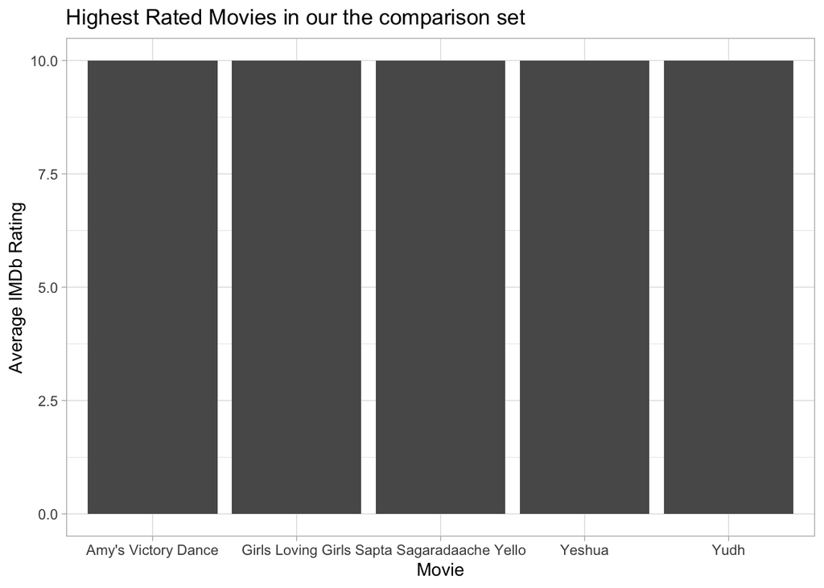

```r
comparison.set %>%
  slice_max(n = 5, averageRating) %>%
  head(5) %>% # randomly take 5 movies
  ggplot(aes(x = reorder(primaryTitle, -averageRating), y = averageRating)) +
  geom_bar(stat = "identity") +
  ggtitle("Highest Rated Movies in our the comparison set") +
  xlab("Movie") +
  theme(axis.text.x = element_text(angle = 90)) +
  ylab("Average IMDb Rating") +
  theme_light()
```

Finally, we can examine how many Academy Awards these movies have received, first in terms of nominations and then actually winning.

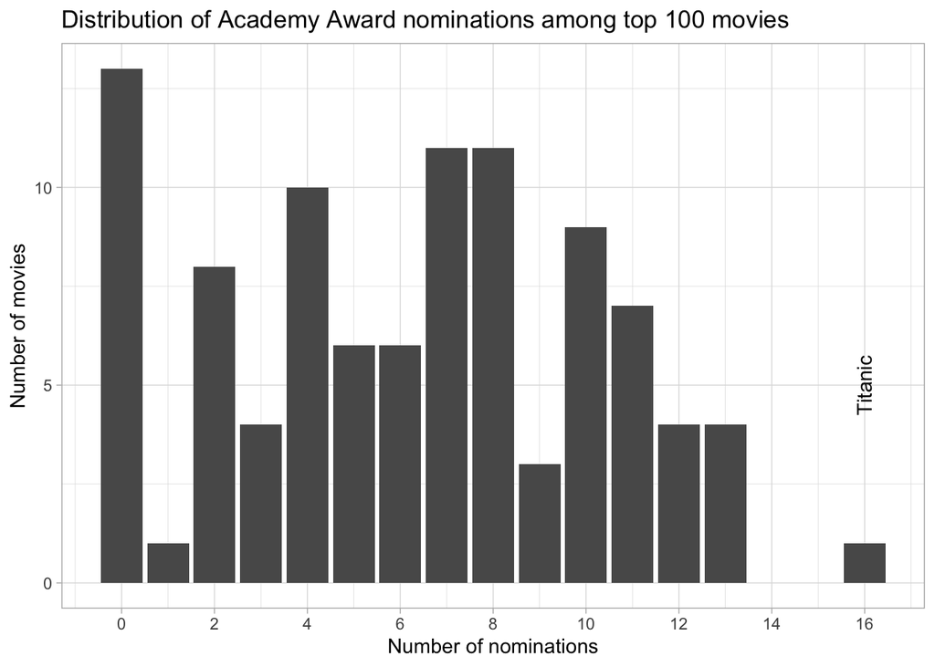

```r
movie.dataset %>%
  ggplot(aes(x = n_nominations)) +
  geom_bar() +
  scale_x_continuous(breaks = scales::pretty_breaks(n = 12)) +
  geom_text(data=subset(movie.dataset, n_nominations>15), aes(y = 5, label=primaryTitle),
                  position= position_dodge(width=0.9), angle = 90) +
  ylab("Number of movies") +
  xlab("Number of nominations") +
  ggtitle("Distribution of Academy Award nominations among top 100 movies") +
  theme_light()
```

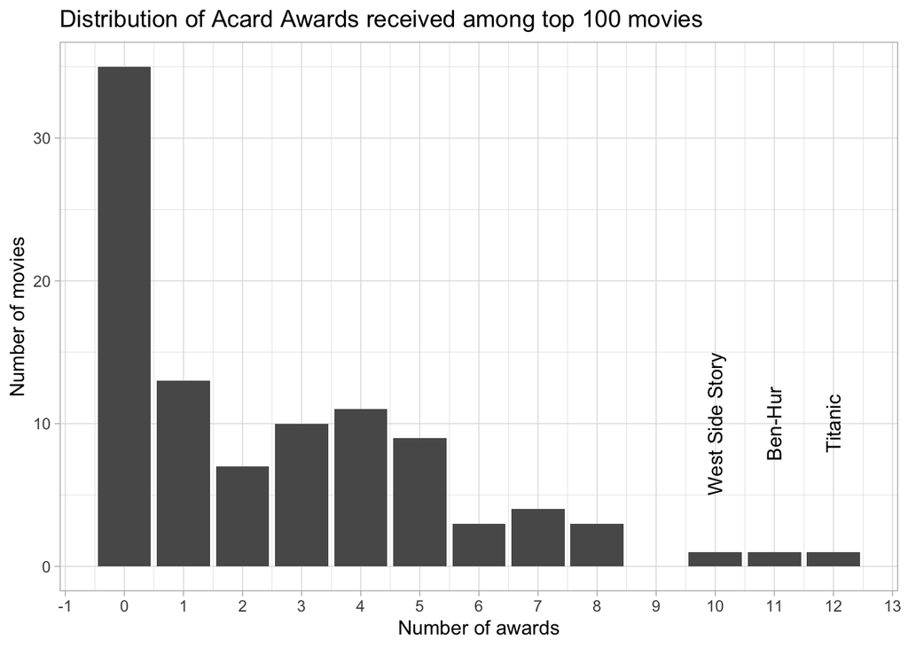

```r
movie.dataset %>%
  ggplot(aes(x = n_awards)) +
  geom_bar() +
  scale_x_continuous(breaks = scales::pretty_breaks(n = 12)) +
  ylab("Number of movies") +
  xlab("Number of awards") +
  geom_text(data=subset(movie.dataset, n_awards>9), aes(y = 10, label=primaryTitle),
                  position= position_dodge(width=0.9), angle = 90) +
  ggtitle("Distribution of Acard Awards received among top 100 movies") +
  theme_light()
```